# Delimited Text

Andrew Ba Tran

This is from the [second chapter](https://learn.r-journalism.com/endelimited-text/) of [learn.r-journalism.com](https://learn.r-journalism.com/).

Sometimes you’ll encounter data with values that are delimited (separated) by characters other than commas. For example, I once received a spreadsheet delimited with emojis.

If opened in a spreadsheet app, the delimited file would be interpreted like any other spreadsheet.

But this is how a pipe-delimited file looks like internally.

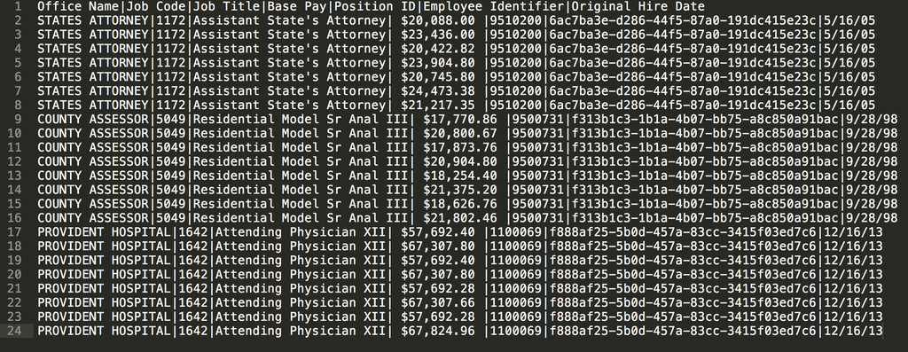

And this is how a tab-delimited file looks.

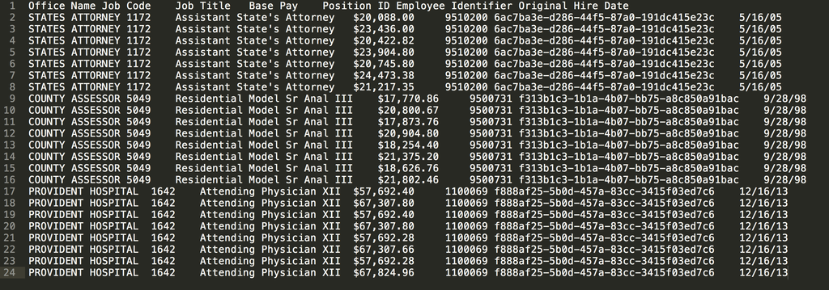

In base R, the way to import these files is to use the `read.table()` function.

You pass it the location of the file (in this case, it’s in the sub directory “data”) and whether it has a header row or not and what separator symbol to look for

```r
# read.table(file,  header=logical_value, sep="delimiter")
df1 <- read.table("data/Employee_Payroll_Pipe.txt", header=TRUE, sep="|")
```

```
View(df1)
```

```r
# a \t indicates a tab (and a \n indicates a line break, like pressing enter in a document)
df2 <- read.table("data/Employee_Payroll_Tab.txt",  header=TRUE, sep="\t")
```

```
View(df2)
```

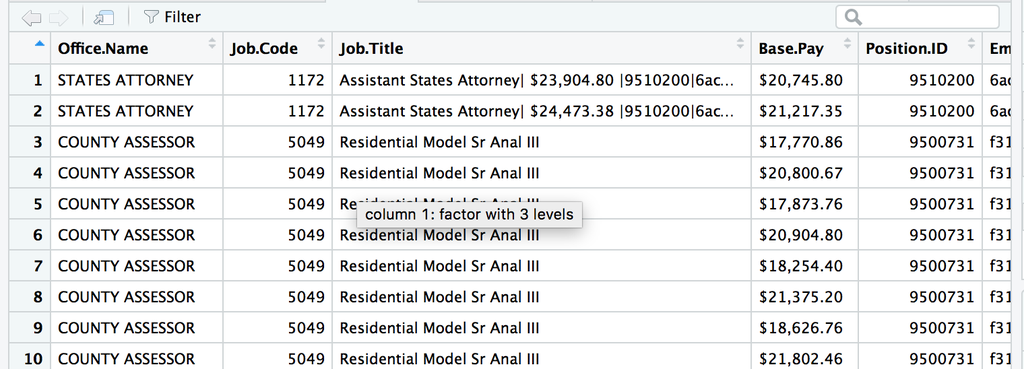